# Ejemplo Market Basket Analysis

Ramiro Casó - Incae Business School

4/20/2021

### El Data Set y las reglas.

Para este ejemplo, estamos usando el dataset `Groceries` que viene en el paquete `arules`, un paquete específico para construir y visualizar reglas de asociación.

Se usa la función `apriori` para hallar las reglas.

```r
glimpse(Groceries)
```

```
## Formal class 'transactions' [package "arules"] with 3 slots
##   ..@ data       :Formal class 'ngCMatrix' [package "Matrix"] with 5 slots
##   ..@ itemInfo   :'data.frame':  169 obs. of  3 variables:
##   .. ..$ labels: chr [1:169] "frankfurter" "sausage" "liver loaf" "ham" ...
##   .. ..$ level2: Factor w/ 55 levels "baby food","bags",..: 44 44 44 44 44 44 44 42 42 41 ...
##   .. ..$ level1: Factor w/ 10 levels "canned food",..: 6 6 6 6 6 6 6 6 6 6 ...
##   ..@ itemsetInfo:'data.frame':  0 obs. of  0 variables
```

```r
summary(Groceries)
```

```
## transactions as itemMatrix in sparse format with
##  9835 rows (elements/itemsets/transactions) and
##  169 columns (items) and a density of 0.02609146
##
## most frequent items:
##       whole milk other vegetables       rolls/buns             soda
##             2513             1903             1809             1715
##           yogurt          (Other)
##             1372            34055
##
## element (itemset/transaction) length distribution:
## sizes
##    1    2    3    4    5    6    7    8    9   10   11   12   13   14   15   16
## 2159 1643 1299 1005  855  645  545  438  350  246  182  117   78   77   55   46
##   17   18   19   20   21   22   23   24   26   27   28   29   32
##   29   14   14    9   11    4    6    1    1    1    1    3    1
##
##    Min. 1st Qu.  Median    Mean 3rd Qu.    Max.
##   1.000   2.000   3.000   4.409   6.000  32.000
##
## includes extended item information - examples:
##        labels  level2           level1
## 1 frankfurter sausage meat and sausage
## 2     sausage sausage meat and sausage
## 3  liver loaf sausage meat and sausage
```

```r
inspect(head(Groceries, 10))
```

```
##      items
## [1]  {citrus fruit,
##       semi-finished bread,
##       margarine,
##       ready soups}
## [2]  {tropical fruit,
##       yogurt,
##       coffee}
## [3]  {whole milk}
## [4]  {pip fruit,
##       yogurt,
##       cream cheese ,
##       meat spreads}
## [5]  {other vegetables,
##       whole milk,
##       condensed milk,
##       long life bakery product}
## [6]  {whole milk,
##       butter,
##       yogurt,
##       rice,
##       abrasive cleaner}
## [7]  {rolls/buns}
## [8]  {other vegetables,
##       UHT-milk,
##       rolls/buns,
##       bottled beer,
##       liquor (appetizer)}
## [9]  {pot plants}
## [10] {whole milk,
##       cereals}
```

### Construyendo las reglas y revisando las reglas.

Para hacer las reglas, utilizaremos la función `apriori` que pide como parámetros el set de datos y que definamos los valores de suporte y confianza que deseamos.

```r
groc_rules <- apriori(Groceries, parameter = list(supp=0.01, conf=0.03, target="rules"))
```

```
## Apriori
##
## Parameter specification:
##  confidence minval smax arem  aval originalSupport maxtime support minlen
##        0.03    0.1    1 none FALSE            TRUE       5    0.01      1
##  maxlen target  ext
##      10  rules TRUE
##
## Algorithmic control:
##  filter tree heap memopt load sort verbose
##     0.1 TRUE TRUE  FALSE TRUE    2    TRUE
##
## Absolute minimum support count: 98
##
## set item appearances ...[0 item(s)] done [0.00s].
## set transactions ...[169 item(s), 9835 transaction(s)] done [0.00s].
## sorting and recoding items ... [88 item(s)] done [0.00s].
## creating transaction tree ... done [0.00s].
## checking subsets of size 1 2 3 4 done [0.00s].
## writing ... [566 rule(s)] done [0.00s].
## creating S4 object  ... done [0.00s].
```

```r
inspect(subset(groc_rules, lift > 2))
```

```
##       lhs                        rhs                     support confidence   coverage     lift count
## [1]   {onions}                => {other vegetables}   0.01423488 0.45901639 0.03101169 2.372268   140
## [2]   {other vegetables}      => {onions}             0.01423488 0.07356805 0.19349263 2.372268   140
## [3]   {berries}               => {yogurt}             0.01057448 0.31804281 0.03324860 2.279848   104
## [4]   {yogurt}                => {berries}            0.01057448 0.07580175 0.13950178 2.279848   104
## [5]   {hamburger meat}        => {other vegetables}   0.01382816 0.41590214 0.03324860 2.149447   136
## [6]   {other vegetables}      => {hamburger meat}     0.01382816 0.07146611 0.19349263 2.149447   136
## [7]   {cream cheese }         => {yogurt}             0.01240468 0.31282051 0.03965430 2.242412   122
## [8]   {yogurt}                => {cream cheese }      0.01240468 0.08892128 0.13950178 2.242412   122
## [9]   {chicken}               => {root vegetables}    0.01087951 0.25355450 0.04290798 2.326221   107
## [10]  {root vegetables}       => {chicken}            0.01087951 0.09981343 0.10899847 2.326221   107
## [11]  {chicken}               => {other vegetables}   0.01789527 0.41706161 0.04290798 2.155439   176
## [12]  {other vegetables}      => {chicken}            0.01789527 0.09248555 0.19349263 2.155439   176
## [13]  {frozen vegetables}     => {root vegetables}    0.01159126 0.24101480 0.04809354 2.211176   114
## [14]  {root vegetables}       => {frozen vegetables}  0.01159126 0.10634328 0.10899847 2.211176   114
## [15]  {beef}                  => {root vegetables}    0.01738688 0.33139535 0.05246568 3.040367   171
## [16]  {root vegetables}       => {beef}               0.01738688 0.15951493 0.10899847 3.040367   171
## [17]  {curd}                  => {whipped/sour cream} 0.01047280 0.19656489 0.05327911 2.742150   103
## [18]  {whipped/sour cream}    => {curd}               0.01047280 0.14609929 0.07168277 2.742150   103
## [19]  {curd}                  => {yogurt}             0.01728521 0.32442748 0.05327911 2.325615   170
## [20]  {yogurt}                => {curd}               0.01728521 0.12390671 0.13950178 2.325615   170
## [21]  {pork}                  => {root vegetables}    0.01362481 0.23633157 0.05765125 2.168210   134
## [22]  {root vegetables}       => {pork}               0.01362481 0.12500000 0.10899847 2.168210   134
## [23]  {butter}                => {whipped/sour cream} 0.01016777 0.18348624 0.05541434 2.559698   100
## [24]  {whipped/sour cream}    => {butter}             0.01016777 0.14184397 0.07168277 2.559698   100
## [25]  {butter}                => {root vegetables}    0.01291307 0.23302752 0.05541434 2.137897   127
## [26]  {root vegetables}       => {butter}             0.01291307 0.11847015 0.10899847 2.137897   127
## [27]  {domestic eggs}         => {root vegetables}    0.01433655 0.22596154 0.06344687 2.073071   141
## [28]  {root vegetables}       => {domestic eggs}      0.01433655 0.13152985 0.10899847 2.073071   141
## [29]  {whipped/sour cream}    => {root vegetables}    0.01708185 0.23829787 0.07168277 2.186250   168
## [30]  {root vegetables}       => {whipped/sour cream} 0.01708185 0.15671642 0.10899847 2.186250   168
## [31]  {whipped/sour cream}    => {yogurt}             0.02074225 0.28936170 0.07168277 2.074251   204
## [32]  {yogurt}                => {whipped/sour cream} 0.02074225 0.14868805 0.13950178 2.074251   204
## [33]  {whipped/sour cream}    => {other vegetables}   0.02887646 0.40283688 0.07168277 2.081924   284
## [34]  {other vegetables}      => {whipped/sour cream} 0.02887646 0.14923805 0.19349263 2.081924   284
## [35]  {pip fruit}             => {citrus fruit}       0.01382816 0.18279570 0.07564820 2.208594   136
## [36]  {citrus fruit}          => {pip fruit}          0.01382816 0.16707617 0.08276563 2.208594   136
## [37]  {pip fruit}             => {tropical fruit}     0.02043721 0.27016129 0.07564820 2.574648   201
## [38]  {tropical fruit}        => {pip fruit}          0.02043721 0.19476744 0.10493137 2.574648   201
## [39]  {citrus fruit}          => {tropical fruit}     0.01992883 0.24078624 0.08276563 2.294702   196
```

[output cut: 106 more lines]

```
##        rolls/buns}            => {root vegetables}    0.01220132 0.28639618 0.04260295 2.627525   120
## [96]  {root vegetables,
##        rolls/buns}            => {whole milk}         0.01270971 0.52301255 0.02430097 2.046888   125
## [97]  {whole milk,
##        rolls/buns}            => {root vegetables}    0.01270971 0.22441652 0.05663447 2.058896   125
## [98]  {root vegetables,
##        whole milk}            => {other vegetables}   0.02318251 0.47401247 0.04890696 2.449770   228
## [99]  {other vegetables,
##        whole milk}            => {root vegetables}    0.02318251 0.30978261 0.07483477 2.842082   228
## [100] {other vegetables,
##        yogurt}                => {whole milk}         0.02226741 0.51288056 0.04341637 2.007235   219
## [101] {whole milk,
##        yogurt}                => {other vegetables}   0.02226741 0.39745917 0.05602440 2.054131   219
## [102] {other vegetables,
##        whole milk}            => {yogurt}             0.02226741 0.29755435 0.07483477 2.132979   219
```

También podemos ver un gráfico que nos presenta las reglas en un scatterplot que tiene la confianza en el eje de las Y’s, el soporte en el eje de las X’s y que usa el tono del color para señalar el lift, con colores más oscuros para lifs más altos.

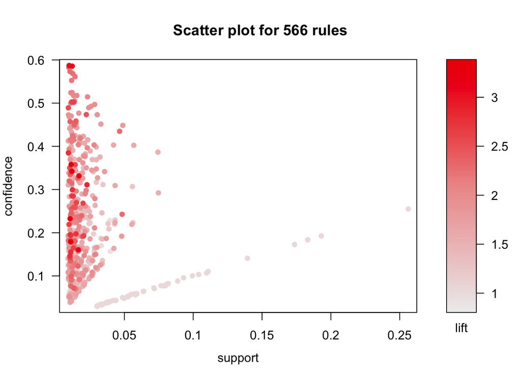

```r
plot(groc_rules, interactive = FALSE)
```

```r
groc_hi <- head(sort(groc_rules, by="lift"), 10)
inspect(groc_hi)
```

```
##      lhs                                  rhs                  support
## [1]  {whole milk,yogurt}               => {curd}               0.01006609
## [2]  {citrus fruit,other vegetables}   => {root vegetables}    0.01037112
## [3]  {other vegetables,yogurt}         => {whipped/sour cream} 0.01016777
## [4]  {tropical fruit,other vegetables} => {root vegetables}    0.01230300
## [5]  {root vegetables}                 => {beef}               0.01738688
## [6]  {beef}                            => {root vegetables}    0.01738688
## [7]  {citrus fruit,root vegetables}    => {other vegetables}   0.01037112
## [8]  {tropical fruit,root vegetables}  => {other vegetables}   0.01230300
## [9]  {other vegetables,whole milk}     => {root vegetables}    0.02318251
## [10] {other vegetables,whole milk}     => {butter}             0.01148958
##      confidence coverage   lift     count
## [1]  0.1796733  0.05602440 3.372304  99
## [2]  0.3591549  0.02887646 3.295045 102
## [3]  0.2341920  0.04341637 3.267062 100
## [4]  0.3427762  0.03589222 3.144780 121
## [5]  0.1595149  0.10899847 3.040367 171
## [6]  0.3313953  0.05246568 3.040367 171
## [7]  0.5862069  0.01769192 3.029608 102
## [8]  0.5845411  0.02104728 3.020999 121
## [9]  0.3097826  0.07483477 2.842082 228
## [10] 0.1535326  0.07483477 2.770630 113
```

Hecho esto, podemos hacer un plot especial, que nos muestras las reglas completas, junto con un indicador del support (diámetro de los círculos) y lift (color)

[output not shown]

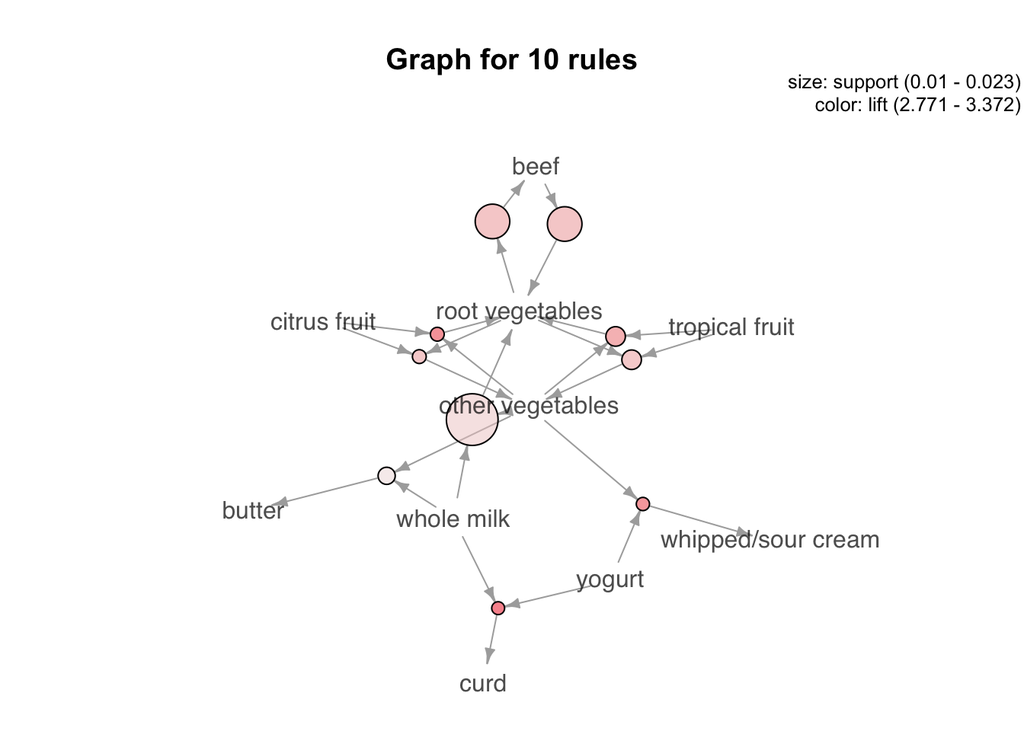

```r
plot(groc_hi, method = "graph", control = list(type="items"))
```

### Filtremos las reglas por confianza

También podemos filtrar las reglas por confianza

```r
groc_hi_conf <- head(sort(groc_rules, by="confidence"), 5)
inspect(groc_hi_conf)
```

```
##     lhs                                 rhs                support
## [1] {citrus fruit,root vegetables}   => {other vegetables} 0.01037112
## [2] {tropical fruit,root vegetables} => {other vegetables} 0.01230300
## [3] {curd,yogurt}                    => {whole milk}       0.01006609
## [4] {other vegetables,butter}        => {whole milk}       0.01148958
## [5] {tropical fruit,root vegetables} => {whole milk}       0.01199797
##     confidence coverage   lift     count
## [1] 0.5862069  0.01769192 3.029608 102
## [2] 0.5845411  0.02104728 3.020999 121
## [3] 0.5823529  0.01728521 2.279125  99
## [4] 0.5736041  0.02003050 2.244885 113
## [5] 0.5700483  0.02104728 2.230969 118
```

[output not shown]

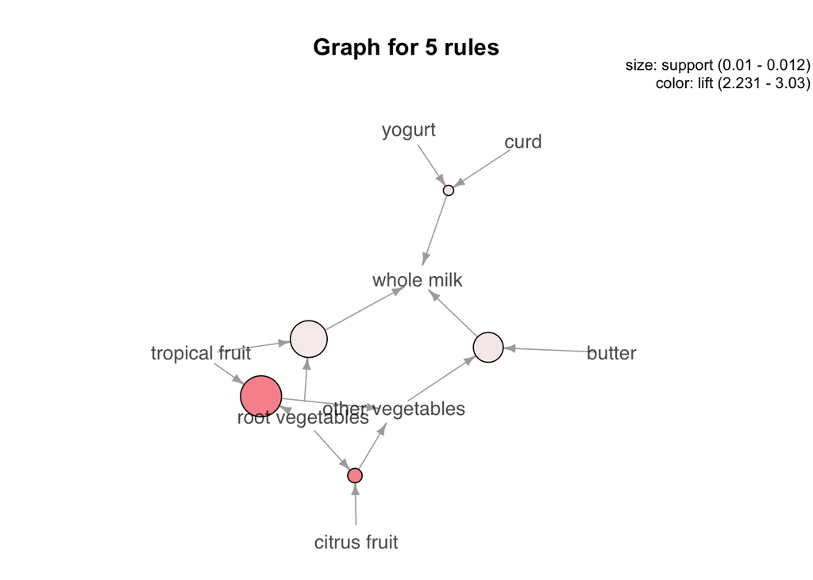

```r
plot(groc_hi_conf, method = "graph", control = list(type="items"))
```